# Visualization

Similarly, let's first check out the overall distribution of color of diamonds. Slightly different but, each one of color is well-distributed and when we divde into two groups, colorless(D,E,F) and near-colorless(G,H,I,J), they have almost the same number of counts.

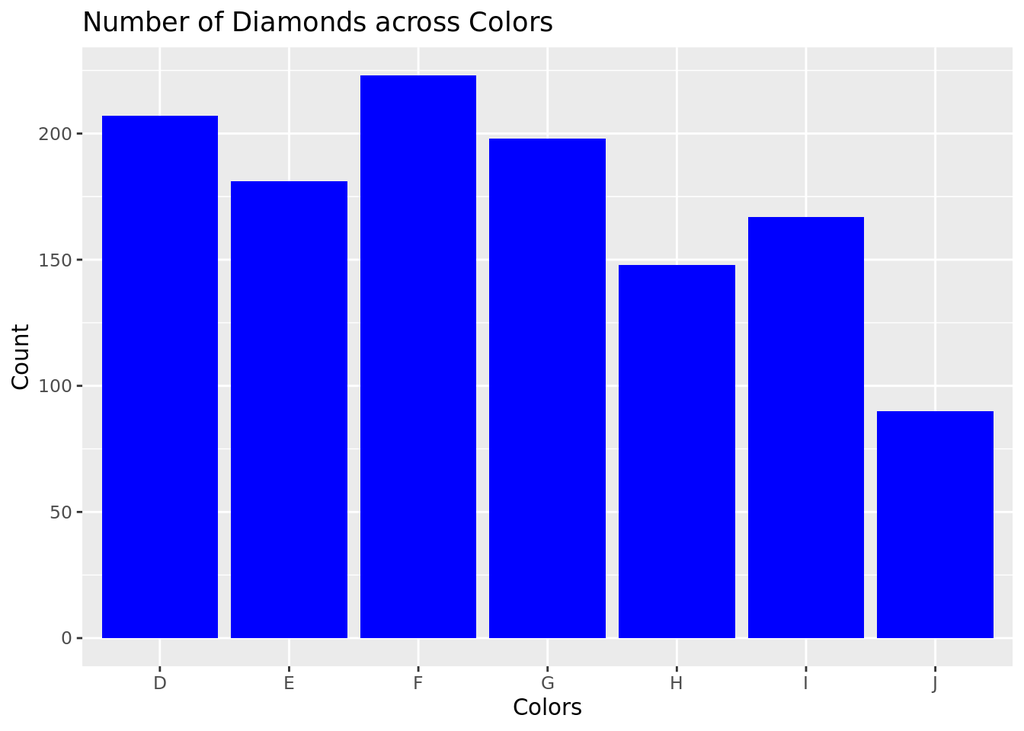

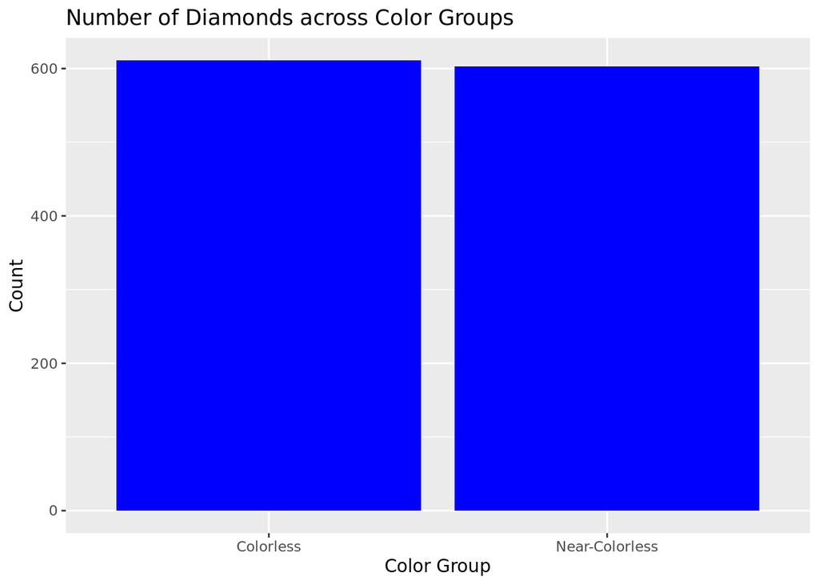

In this boxplot, it seems that price matches the high value of orders in colors (alphebatical order form D to J). After we divide colors into two subgroups(colorless & near-colorless) and look at the boxplot, overall height of two boxes are similar, but when it comes to outlier points, colorless group had observations with slightly higher prices.

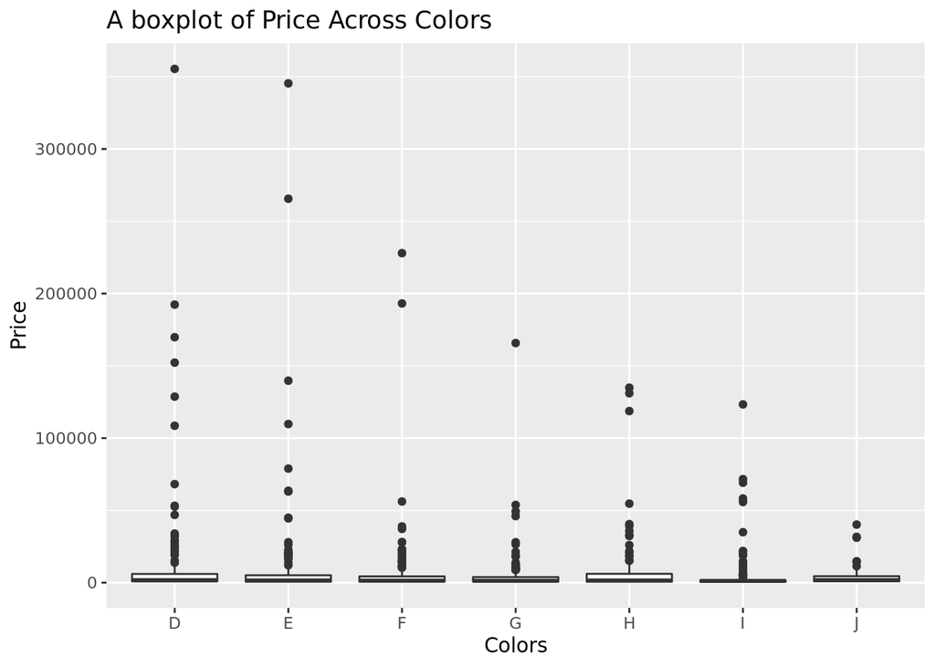

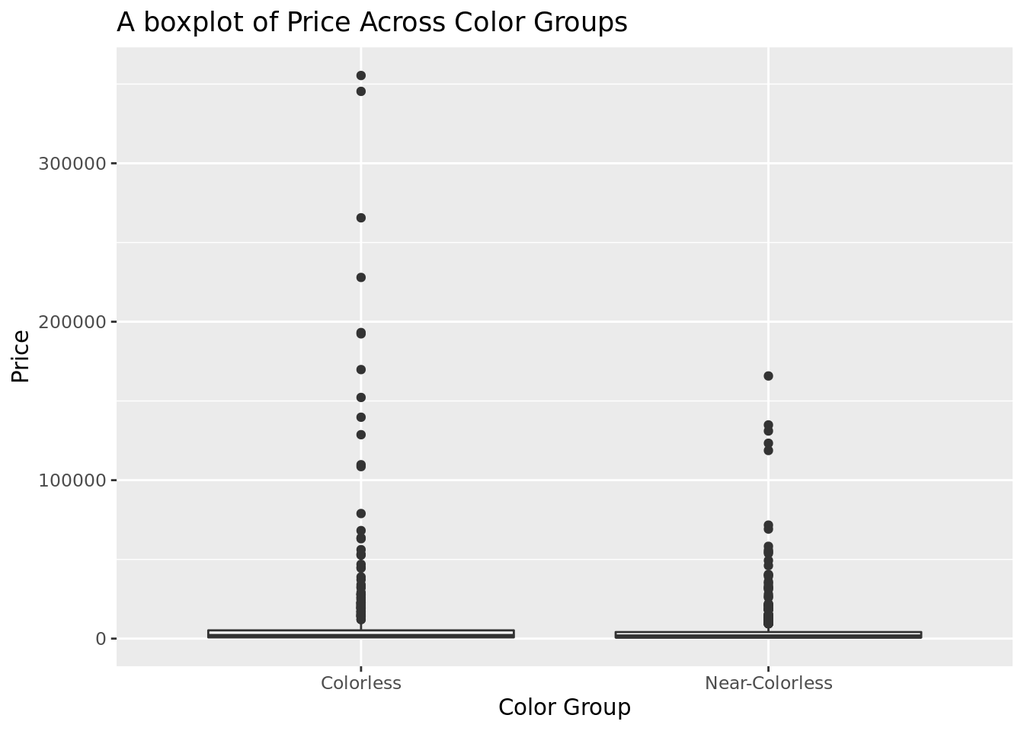

Now, in order to eliminate the effects of outliers, let's work on reduced-price dataset with price < $50,000. From below two boxplots, overall vertical spread seems to be similar.

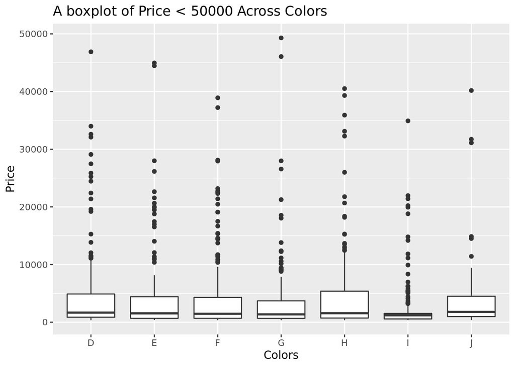

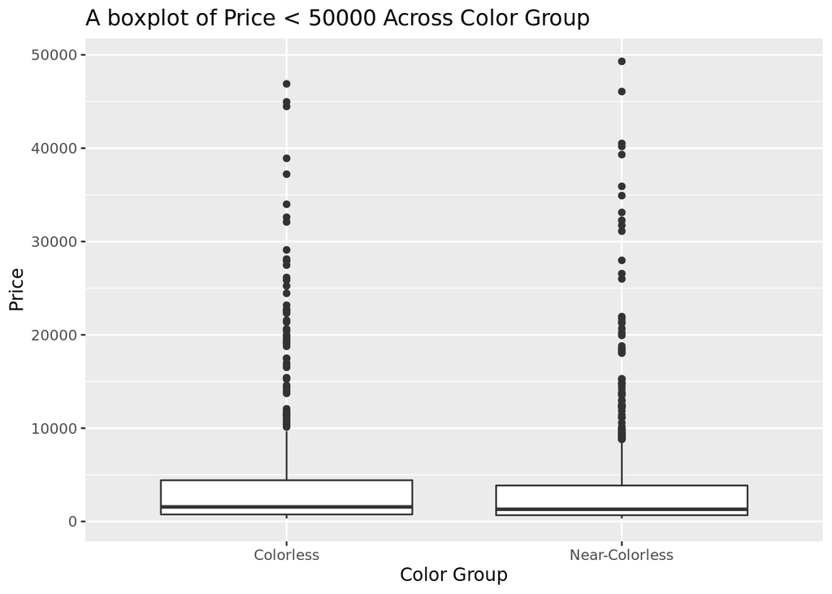

However, as the boxplot does not provide good information on median values, we use summarized table.

For color groups (colorless ~ near-colorless), on both full-priced datset and reduced dataset, **colorless diamonds were slightly more expensive than near-colorless diamonds, which is in line with claims made on the website.**

```
## # A tibble: 2 × 5
##   color_group    count mean_price median_price     sd
##   <chr>          <int>      <dbl>        <int>  <dbl>
## 1 Colorless        611      8765.         1607 30649.
## 2 Near-Colorless   603      5326.         1334 14651.
```

```
## # A tibble: 2 × 5
##   color_group    count mean_price median_price    sd
##   <chr>          <int>      <dbl>        <dbl> <dbl>
## 1 Colorless        592      4275.        1564. 6777.
## 2 Near-Colorless   592      3673.        1310. 6360.
```

For colors (D ~ J), the intersting result is that **the lowest color grade, J, tends to have the highest median price both on full-priced datset and reduced dataset, which is counterintuitive and objects the claims made on the website: Diamond prices decline or increase in alphabetical order.** However, this observation cannot necessarily lead to the claim that 'color is not a determining factor of diamond price as the diamonds wit the lowest color grade J, had the highest median price.'

```
## # A tibble: 7 × 5
##   color count mean_price median_price     sd
##   <fct> <int>      <dbl>        <dbl>  <dbl>
## 1 D       207     10525.         1781 34485.
## 2 E       181      9906.         1602 35687.
## 3 F       223      6205.         1485 20846.
## 4 G       198      4572.         1374 13555.
## 5 H       148      7799.         1575 19433.
## 6 I       167      4779.         1212 14006.
## 7 J        90      3934.         1803  6456.
```

```
## # A tibble: 7 × 5
##   color count mean_price median_price    sd
##   <fct> <int>      <dbl>        <dbl> <dbl>
## 1 D       198      4534.        1666. 7100.
## 2 E       174      4178.        1532. 6929.
## 3 F       220      4120.        1474. 6370.
## 4 G       196      3498.        1354. 6229.
## 5 H       144      4964.        1548  7720.
## 6 I       162      2593.        1192. 4771.
## 7 J        90      3934.        1803  6456.
```

When we also take into account median carat to two groups, there is no significant difference between both in mean carat and median price between two groups, but colorless diamonds are both higher in median carats and median price than near-colorless diamonds. However, if we surely want to verify the median difference of crat between colorless group and non-colorless group, additional simple t-test between two groups should be implemented.

```
## # A tibble: 2 × 3
##   color_group    median_carat median_price
##   <chr>                 <dbl>        <int>
## 1 Colorless              0.53         1607
## 2 Near-Colorless         0.51         1334
```

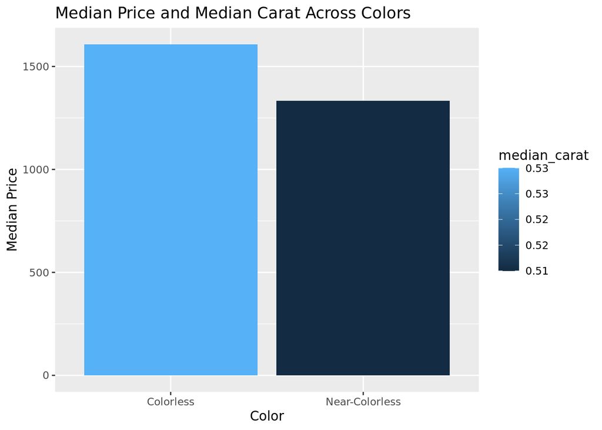

When we look at the barplot below, across all colors, median prices from all colors are different due to different median carats. In order to verify the claim that 'diamond prices decline or increase in alphabetical order', we need to compare multiple diamonds with all of other factors being equal but different colors. However, in this dataset, we cannot find observations that satisfy the requiremnts. To sum up, in terms of color, diamonds with color 'J' has the highest median price but this is because it also has the highest median carat compared to other diamonds with different colors.

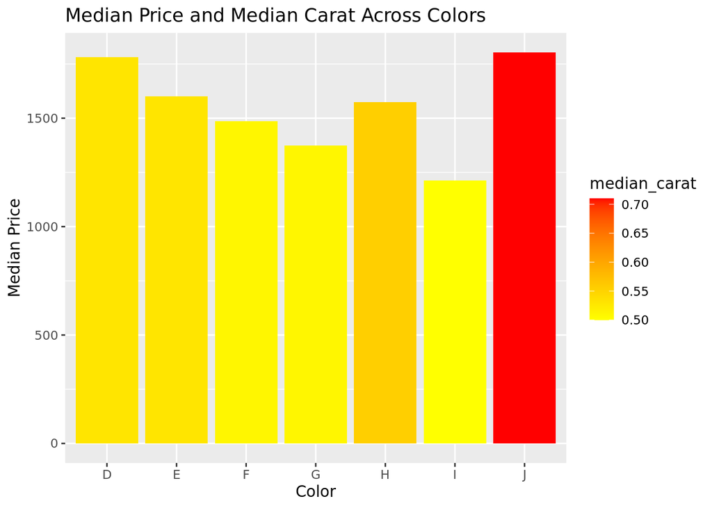

To sum up, we can observe that in terms of diamond color groups (colorless & near-colorless), colorless diamonds have higher median prices than those of near-colorless counterpart. In terms of diamond colors, diamonds with the lowest color grade, 'J' has the highest median prices. However, it is still unclear to affirm that particular diamond color group and diamond color determines the price of diamond because they actually turn out to be diamonds with high-carats.

** 3. On Cut **

Most diamonds are found to be ideal and very good in terms of cut.

[figure not shown]

## Overal spread of cut

: The top three expensive diamonds are turned out to be from ideal and very good cut, not from astor ideal cut.

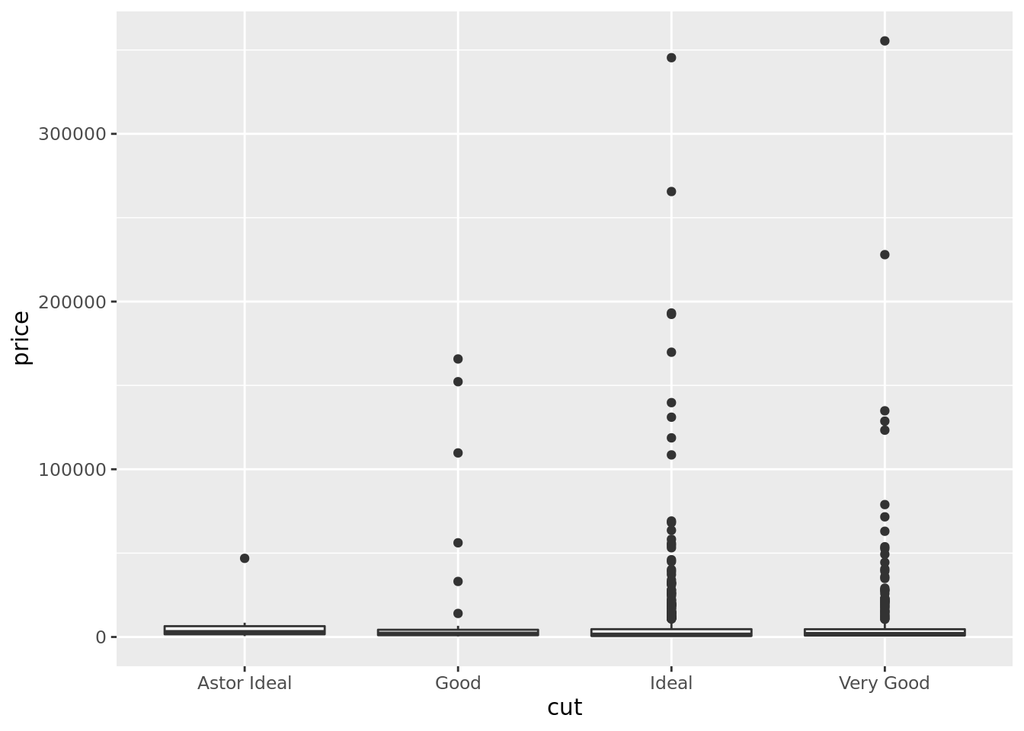

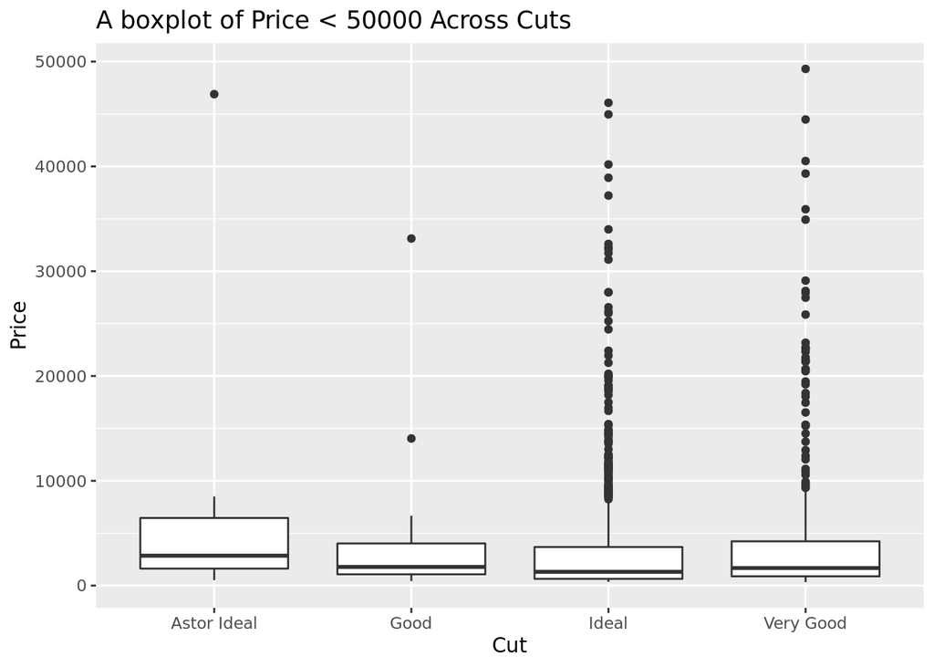

When we take a look at both full-price and reduced-prcie diamond dataset, Astor Ideal has the highest median price, then good, very good, and ideal.

```
## # A tibble: 4 × 5
##   cut         count mean_price median_price     sd
##   <fct>       <int>      <dbl>        <dbl>  <dbl>
## 1 Astor Ideal    20      5852.        2854  10014.
## 2 Good           73      9467.        1903  29143.
## 3 Ideal         739      6489.        1354  22942.
## 4 Very Good     382      7758.        1744. 25792.
```

```
## # A tibble: 4 × 5
##   cut         count mean_price median_price     sd
##   <fct>       <int>      <dbl>        <dbl>  <dbl>
## 1 Astor Ideal    20      5852.         2854 10014.
## 2 Good           69      3003.         1781  4253.
## 3 Ideal         723      3746.         1313  6233.
## 4 Very Good     372      4498.         1676  7285.
```

This barplot does not 100 % jibe with the claim made in the website: **" In reality, it’s the cut of the diamond that can be the biggest factor in the price tag. The Ideal cut diamond, and the super-ideal Astor by Blue Nile™, are the most expensive diamond cuts because they optimize light performance and create the most impressive sparkle."** Similar to the graph found in 'color' section, most of pricy diamonds are found to be higher in carats. Therfore, in order to identify linear relationsihp between cuts and prices, additional simple linear regression should be implemented.

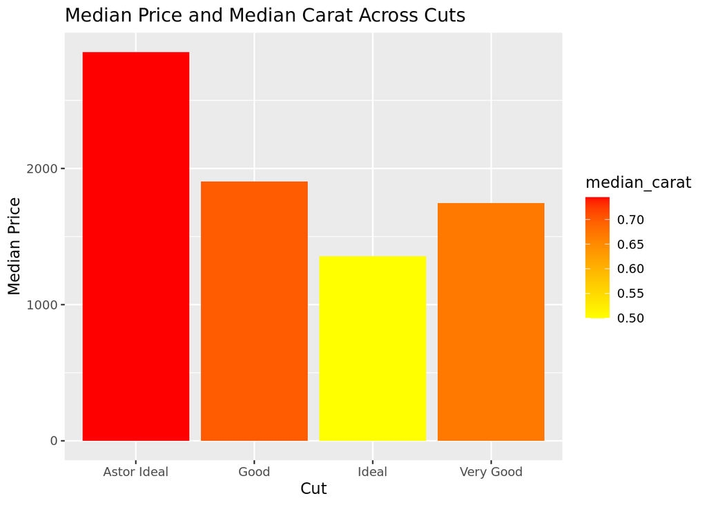